[figure not shown]

# JoinNode

JoinNode have the opposite effect of iterables. Where `iterables` split up the execution workflow into many different branches, a JoinNode merges them back into on node. For a more detailed explanation, check out [JoinNode, synchronize and itersource](http://nipype.readthedocs.io/en/latest/users/joinnode_and_itersource.html) from the main homepage.

## Simple example

Let's consider the very simple example depicted at the top of this page:

```
from nipype import Node, JoinNode, Workflow

# Specify fake input node A
a = Node(interface=A(), name="a")

# Iterate over fake node B's input 'in_file?
b = Node(interface=B(), name="b")
b.iterables = ('in_file', [file1, file2])

# Pass results on to fake node C
c = Node(interface=C(), name="c")

# Join forked execution workflow in fake node D
d = JoinNode(interface=D(),
             joinsource="b",
             joinfield="in_files",
             name="d")

# Put everything into a workflow as usual
workflow = Workflow(name="workflow")
workflow.connect([(a, b, [('subject', 'subject')]),
                  (b, c, [('out_file', 'in_file')])
                  (c, d, [('out_file', 'in_files')])
                  ])
```

As you can see, setting up a `JoinNode` is rather simple. The only difference to a normal `Node` are the `joinsource` and the `joinfield`. `joinsource` specifies from which node the information to join is coming and the `joinfield` specifies the input field of the JoinNode where the information to join will be entering the node.

## More realistic example

Let's consider another example where we have one node that iterates over 3 different numbers and generates randome numbers. Another node joins those three different numbers (each coming from a separate branch of the workflow) into one list. To make the whole thing a bit more realistic, the second node will use the `Function` interface to do something with those numbers, before we spit them out again.

```python
from nipype import JoinNode, Node, Workflow
from nipype.interfaces.utility import Function, IdentityInterface
```

```python
def get_data_from_id(id):
    """Generate a random number based on id"""
    import numpy as np
    return id + np.random.rand()

def merge_and_scale_data(data2):
    """Scale the input list by 1000"""
    import numpy as np
    return (np.array(data2) * 1000).tolist()


node1 = Node(Function(input_names=['id'],
                      output_names=['data1'],
                      function=get_data_from_id),
             name='get_data')
node1.iterables = ('id', [1, 2, 3])

node2 = JoinNode(Function(input_names=['data2'],
                          output_names=['data_scaled'],
                          function=merge_and_scale_data),
                 name='scale_data',
                 joinsource=node1,
                 joinfield=['data2'])
```

```python
wf = Workflow(name='testjoin')
wf.connect(node1, 'data1', node2, 'data2')
eg = wf.run()
```

```
180325-18:01:22,677 workflow INFO:
	 Workflow testjoin settings: ['check', 'execution', 'logging', 'monitoring']
180325-18:01:22,686 workflow INFO:
	 Running serially.
180325-18:01:22,687 workflow INFO:
	 [Node] Setting-up "testjoin.get_data" in "/tmp/tmpk9_88rbo/testjoin/_id_3/get_data".
180325-18:01:22,692 workflow INFO:
	 [Node] Running "get_data" ("nipype.interfaces.utility.wrappers.Function")
180325-18:01:22,701 workflow INFO:
	 [Node] Finished "testjoin.get_data".
180325-18:01:22,706 workflow INFO:
	 [Node] Setting-up "testjoin.get_data" in "/tmp/tmpy66z155p/testjoin/_id_2/get_data".
180325-18:01:22,711 workflow INFO:
	 [Node] Running "get_data" ("nipype.interfaces.utility.wrappers.Function")
180325-18:01:22,717 workflow INFO:
	 [Node] Finished "testjoin.get_data".
180325-18:01:22,718 workflow INFO:
	 [Node] Setting-up "testjoin.get_data" in "/tmp/tmpekhy6hum/testjoin/_id_1/get_data".
180325-18:01:22,725 workflow INFO:
	 [Node] Running "get_data" ("nipype.interfaces.utility.wrappers.Function")
180325-18:01:22,735 workflow INFO:
	 [Node] Finished "testjoin.get_data".
180325-18:01:22,740 workflow INFO:
	 [Node] Setting-up "testjoin.scale_data" in "/tmp/tmphwyybl05/testjoin/scale_data".
180325-18:01:22,750 workflow INFO:
	 [Node] Running "scale_data" ("nipype.interfaces.utility.wrappers.Function")
180325-18:01:22,758 workflow INFO:
	 [Node] Finished "testjoin.scale_data".
```

```
180325-18:01:23,128 workflow INFO:
	 Generated workflow graph: /home/neuro/nipype_tutorial/notebooks/graph.png (graph2use=exec, simple_form=True).
```

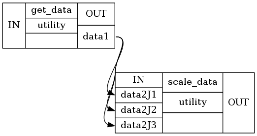

```python
wf.write_graph(graph2use='exec')
from IPython.display import Image
Image(filename='graph_detailed.png')
```

Now, let's look at the input and output of the joinnode:

```python
res = [node for node in eg.nodes() if 'scale_data' in node.name][0].result
res.outputs
```

```
data_scaled = [1078.772769485424, 2926.89657793694, 3112.781476601858]
```

```python
res.inputs
```

```
{'data2': [1.078772769485424, 2.9268965779369402, 3.1127814766018576],
 'function_str': 'def merge_and_scale_data(data2):\n    """Scale the input list by 1000"""\n    import numpy as np\n    return (np.array(data2) * 1000).tolist()\n',
 'ignore_exception': False}
```

## Extending to multiple nodes

We extend the workflow by using three nodes. Note that even this workflow, the joinsource corresponds to the node containing iterables and the joinfield corresponds to the input port of the JoinNode that aggregates the iterable branches. As before the graph below shows how the execution process is setup.

```python
def get_data_from_id(id):
    import numpy as np
    return id + np.random.rand()

def scale_data(data2):
    import numpy as np
    return data2

def replicate(data3, nreps=2):
    return data3 * nreps

node1 = Node(Function(input_names=['id'],
                      output_names=['data1'],
                      function=get_data_from_id),
             name='get_data')
node1.iterables = ('id', [1, 2, 3])

node2 = Node(Function(input_names=['data2'],
                      output_names=['data_scaled'],
                      function=scale_data),
             name='scale_data')

node3 = JoinNode(Function(input_names=['data3'],
                          output_names=['data_repeated'],
                          function=replicate),
                 name='replicate_data',
                 joinsource=node1,
                 joinfield=['data3'])
```

```python
wf = Workflow(name='testjoin')
wf.connect(node1, 'data1', node2, 'data2')
wf.connect(node2, 'data_scaled', node3, 'data3')
eg = wf.run()
```

```
180325-18:01:23,270 workflow INFO:
	 Workflow testjoin settings: ['check', 'execution', 'logging', 'monitoring']
180325-18:01:23,291 workflow INFO:
	 Running serially.
180325-18:01:23,294 workflow INFO:
	 [Node] Setting-up "testjoin.get_data" in "/tmp/tmp5_fxttau/testjoin/_id_3/get_data".
180325-18:01:23,310 workflow INFO:
	 [Node] Running "get_data" ("nipype.interfaces.utility.wrappers.Function")
180325-18:01:23,318 workflow INFO:
	 [Node] Finished "testjoin.get_data".
180325-18:01:23,321 workflow INFO:
	 [Node] Setting-up "testjoin.scale_data" in "/tmp/tmpl6tysqp9/testjoin/_id_3/scale_data".
180325-18:01:23,328 workflow INFO:
	 [Node] Running "scale_data" ("nipype.interfaces.utility.wrappers.Function")
180325-18:01:23,341 workflow INFO:
	 [Node] Finished "testjoin.scale_data".
180325-18:01:23,343 workflow INFO:
	 [Node] Setting-up "testjoin.get_data" in "/tmp/tmpeayvqpbo/testjoin/_id_2/get_data".
180325-18:01:23,352 workflow INFO:
	 [Node] Running "get_data" ("nipype.interfaces.utility.wrappers.Function")
180325-18:01:23,367 workflow INFO:
	 [Node] Finished "testjoin.get_data".
180325-18:01:23,369 workflow INFO:
	 [Node] Setting-up "testjoin.scale_data" in "/tmp/tmpszvkb1ib/testjoin/_id_2/scale_data".
180325-18:01:23,375 workflow INFO:
	 [Node] Running "scale_data" ("nipype.interfaces.utility.wrappers.Function")
180325-18:01:23,383 workflow INFO:
	 [Node] Finished "testjoin.scale_data".
180325-18:01:23,384 workflow INFO:
	 [Node] Setting-up "testjoin.get_data" in "/tmp/tmpz4o9_izq/testjoin/_id_1/get_data".
180325-18:01:23,390 workflow INFO:
	 [Node] Running "get_data" ("nipype.interfaces.utility.wrappers.Function")
180325-18:01:23,400 workflow INFO:
	 [Node] Finished "testjoin.get_data".
180325-18:01:23,402 workflow INFO:
	 [Node] Setting-up "testjoin.scale_data" in "/tmp/tmpvf5jw81q/testjoin/_id_1/scale_data".
180325-18:01:23,407 workflow INFO:
	 [Node] Running "scale_data" ("nipype.interfaces.utility.wrappers.Function")
180325-18:01:23,416 workflow INFO:
	 [Node] Finished "testjoin.scale_data".
180325-18:01:23,418 workflow INFO:
	 [Node] Setting-up "testjoin.replicate_data" in "/tmp/tmp3fkb1o63/testjoin/replicate_data".
180325-18:01:23,426 workflow INFO:
	 [Node] Running "replicate_data" ("nipype.interfaces.utility.wrappers.Function")
180325-18:01:23,435 workflow INFO:
	 [Node] Finished "testjoin.replicate_data".
```

```
180325-18:01:23,712 workflow INFO:
	 Generated workflow graph: /home/neuro/nipype_tutorial/notebooks/graph.png (graph2use=exec, simple_form=True).
```

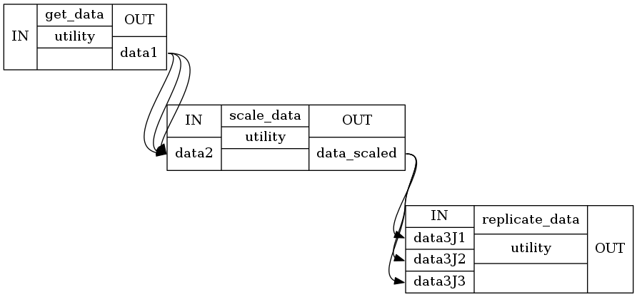

```python
wf.write_graph(graph2use='exec')
Image(filename='graph_detailed.png')
```

### Exercise 1

You have list of DOB of the subjects in a few various format : `["10 February 1984", "March 5 1990", "April 2 1782", "June 6, 1988", "12 May 1992"]`, and you want to sort the list.

You can use `Node` with `iterables` to extract day, month and year, and use [datetime.datetime](https://docs.python.org/2/library/datetime.html) to unify the format that can be compared, and `JoinNode` to sort the list.

```python
# write your solution here
```

```python
# the list of all DOB
dob_subjects = ["10 February 1984", "March 5 1990", "April 2 1782", "June 6, 1988", "12 May 1992"]
```

```python
# let's start from creating Node with iterable to split all strings from the list
from nipype import Node, JoinNode, Function, Workflow

def split_dob(dob_string):
    return dob_string.split()

split_node = Node(Function(input_names=["dob_string"],
                              output_names=["split_list"],
                              function=split_dob),
                    name="splitting")

#split_node.inputs.dob_string = "10 February 1984"
split_node.iterables = ("dob_string", dob_subjects)
```

```python
# and now let's work on the date format more, independently for every element

# sometimes the second element has an extra "," that we should remove
def remove_comma(str_list):
    str_list[1] = str_list[1].replace(",", "")
    return str_list

cleaning_node = Node(Function(input_names=["str_list"],
                              output_names=["str_list_clean"],
                              function=remove_comma),
                    name="cleaning")


# now we can extract year, month, day from our list and create ``datetime.datetim`` object
def datetime_format(date_list):
    import datetime
    # year is always the last
    year = int(date_list[2])
    #day and month can be in the first or second position
    # we can use datetime.datetime.strptime to convert name of the month to integer
    try:
        day = int(date_list[0])
        month = datetime.datetime.strptime(date_list[1], "%B").month
    except(ValueError):
        day = int(date_list[1])
        month = datetime.datetime.strptime(date_list[0], "%B").month
    # and create datetime.datetime format
    return datetime.datetime(year, month, day)


datetime_node = Node(Function(input_names=["date_list"],
                                  output_names=["datetime"],
                              function=datetime_format),
                    name="datetime")
```

```python
# now we are ready to create JoinNode and sort the list of DOB

def sorting_dob(datetime_list):
    datetime_list.sort()
    return datetime_list

sorting_node = JoinNode(Function(input_names=["datetime_list"],
                              output_names=["dob_sorted"],
                              function=sorting_dob),
                    joinsource=split_node, # this is the node that used iterables for x
                    joinfield=['datetime_list'],
                    name="sorting")
```

```python
# and we're ready to create workflow

ex1_wf = Workflow(name="sorting_dob")
ex1_wf.connect(split_node, "split_list", cleaning_node, "str_list")
ex1_wf.connect(cleaning_node, "str_list_clean", datetime_node, "date_list")
ex1_wf.connect(datetime_node, "datetime", sorting_node, "datetime_list")
```

```
180325-18:01:24,153 workflow INFO:
	 Generated workflow graph: /home/neuro/nipype_tutorial/notebooks/graph.png (graph2use=exec, simple_form=True).
```

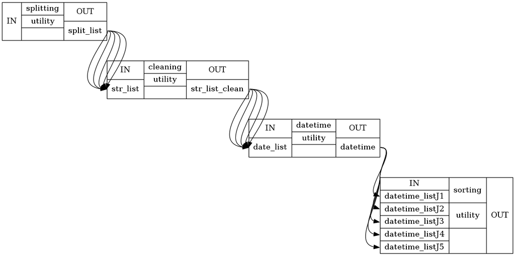

```python
# you can check the graph
from IPython.display import Image
ex1_wf.write_graph(graph2use='exec')
Image(filename='graph_detailed.png')
```

```python
# and run the workflow
ex1_res = ex1_wf.run()
```

```
180325-18:01:24,177 workflow INFO:
	 Workflow sorting_dob settings: ['check', 'execution', 'logging', 'monitoring']
180325-18:01:24,210 workflow INFO:
	 Running serially.
180325-18:01:24,212 workflow INFO:
	 [Node] Setting-up "sorting_dob.splitting" in "/tmp/tmp8oduydpw/sorting_dob/_dob_string_12May1992/splitting".
180325-18:01:24,216 workflow INFO:
	 [Node] Running "splitting" ("nipype.interfaces.utility.wrappers.Function")
180325-18:01:24,226 workflow INFO:
	 [Node] Finished "sorting_dob.splitting".
180325-18:01:24,227 workflow INFO:
	 [Node] Setting-up "sorting_dob.cleaning" in "/tmp/tmpb9dfejrz/sorting_dob/_dob_string_12May1992/cleaning".
180325-18:01:24,235 workflow INFO:
	 [Node] Running "cleaning" ("nipype.interfaces.utility.wrappers.Function")
180325-18:01:24,243 workflow INFO:
	 [Node] Finished "sorting_dob.cleaning".
180325-18:01:24,245 workflow INFO:
	 [Node] Setting-up "sorting_dob.datetime" in "/tmp/tmp6ed1d9o1/sorting_dob/_dob_string_12May1992/datetime".
180325-18:01:24,255 workflow INFO:
	 [Node] Running "datetime" ("nipype.interfaces.utility.wrappers.Function")
180325-18:01:24,264 workflow INFO:
	 [Node] Finished "sorting_dob.datetime".
180325-18:01:24,267 workflow INFO:
	 [Node] Setting-up "sorting_dob.splitting" in "/tmp/tmpvqw672tc/sorting_dob/_dob_string_June6.1988/splitting".
180325-18:01:24,274 workflow INFO:
	 [Node] Running "splitting" ("nipype.interfaces.utility.wrappers.Function")
180325-18:01:24,280 workflow INFO:
	 [Node] Finished "sorting_dob.splitting".
180325-18:01:24,281 workflow INFO:
	 [Node] Setting-up "sorting_dob.cleaning" in "/tmp/tmpui1ife9w/sorting_dob/_dob_string_June6.1988/cleaning".
180325-18:01:24,288 workflow INFO:
	 [Node] Running "cleaning" ("nipype.interfaces.utility.wrappers.Function")
180325-18:01:24,295 workflow INFO:
	 [Node] Finished "sorting_dob.cleaning".
180325-18:01:24,296 workflow INFO:
	 [Node] Setting-up "sorting_dob.datetime" in "/tmp/tmpgxmdxz6p/sorting_dob/_dob_string_June6.1988/datetime".
180325-18:01:24,305 workflow INFO:
	 [Node] Running "datetime" ("nipype.interfaces.utility.wrappers.Function")
180325-18:01:24,311 workflow INFO:
	 [Node] Finished "sorting_dob.datetime".
```

[output cut: 45 more lines]

```
	 [Node] Running "cleaning" ("nipype.interfaces.utility.wrappers.Function")
180325-18:01:24,432 workflow INFO:
	 [Node] Finished "sorting_dob.cleaning".
180325-18:01:24,434 workflow INFO:
	 [Node] Setting-up "sorting_dob.datetime" in "/tmp/tmpd90qcs4r/sorting_dob/_dob_string_10February1984/datetime".
180325-18:01:24,445 workflow INFO:
	 [Node] Running "datetime" ("nipype.interfaces.utility.wrappers.Function")
180325-18:01:24,455 workflow INFO:
	 [Node] Finished "sorting_dob.datetime".
180325-18:01:24,458 workflow INFO:
	 [Node] Setting-up "sorting_dob.sorting" in "/tmp/tmpp64jg2jf/sorting_dob/sorting".
180325-18:01:24,466 workflow INFO:
	 [Node] Running "sorting" ("nipype.interfaces.utility.wrappers.Function")
180325-18:01:24,474 workflow INFO:
	 [Node] Finished "sorting_dob.sorting".
```

```python
# you can check list of all nodes
ex1_res.nodes()
```

```
NodeView((<nipype.pipeline.engine.nodes.JoinNode object at 0x7fe05dea07f0>, <nipype.pipeline.engine.nodes.Node object at 0x7fe05dea0a20>, <nipype.pipeline.engine.nodes.Node object at 0x7fe05dea0b00>, <nipype.pipeline.engine.nodes.Node object at 0x7fe05dea0be0>, <nipype.pipeline.engine.nodes.Node obj…
```

```python
# and check the results from sorting_dob.sorting
list(ex1_res.nodes())[0].result.outputs
```

```
dob_sorted = [datetime.datetime(1782, 4, 2, 0, 0), datetime.datetime(1984, 2, 10, 0, 0), datetime.datetime(1988, 6, 6, 0, 0), datetime.datetime(1990, 3, 5, 0, 0), datetime.datetime(1992, 5, 12, 0, 0)]
```

[Home](https://miykael.github.io/nipype_tutorial/) | [github](https://github.com/miykael/nipype_tutorial) | [Nipype](http://nipype.readthedocs.io)